# Factors Influencing the Length of Stay for Shelter Animals

Author

Group 18

Importing necessary libraries and loading the dataset:

## Introduction

The dataset, acquired from the Dallas animal shelter, encompasses comprehensive information regarding each animal admitted to the facility. It contains vital details such as the type of animal namely {dogs, cats, wildlife, bird, livestock}, the reason for admission, and the eventual outcome i.e whether they were euthanised, returned to the owner, adopted, foster or died. This study aims to investigate a fundamental question:

- **What are the factors that influence the time an animal spends at shelter before their final outcome**

## Exploratory Data Analysis

Taking a closer look at the dataset:

```
  animal_type month year     intake_type      outcome_type  chip_status
1         DOG     8 2017           STRAY RETURNED TO OWNER SCAN NO CHIP
2         DOG     7 2017           STRAY        EUTHANIZED SCAN NO CHIP
3         DOG     1 2017     CONFISCATED          ADOPTION SCAN NO CHIP
4         DOG     6 2017 OWNER SURRENDER          ADOPTION SCAN NO CHIP
5         DOG     4 2017           STRAY          ADOPTION SCAN NO CHIP
6         DOG     7 2017           STRAY RETURNED TO OWNER SCAN NO CHIP
  time_at_shelter
1               2
2              10
3              13
4               7
5               5
6               3
```

```
Rows: 1,135
Columns: 7
$ animal_type     <chr> "DOG", "DOG", "DOG", "DOG", "DOG", "DOG", "DOG", "DOG"…
$ month           <int> 8, 7, 1, 6, 4, 7, 1, 1, 7, 3, 8, 3, 10, 1, 5, 8, 8, 3,…
$ year            <int> 2017, 2017, 2017, 2017, 2017, 2017, 2017, 2017, 2017, …
$ intake_type     <chr> "STRAY", "STRAY", "CONFISCATED", "OWNER SURRENDER", "S…
$ outcome_type    <chr> "RETURNED TO OWNER", "EUTHANIZED", "ADOPTION", "ADOPTI…
$ chip_status     <chr> "SCAN NO CHIP", "SCAN NO CHIP", "SCAN NO CHIP", "SCAN …
$ time_at_shelter <int> 2, 10, 13, 7, 5, 3, 5, 6, 12, 1, 9, 6, 14, 12, 0, 0, 4…
```

Let’s look at the summary statistic for our response variable i.e the time an animal spends at a shelter before their final outcome.

Data summary

| Name | Piped data |
| --- | --- |
| Number of rows | 1135 |
| Number of columns | 1 |
| _______________________ |  |
| Column type frequency: |  |
| numeric | 1 |
| ________________________ |  |
| Group variables | None |

**Variable type: numeric**

| skim_variable | n_missing | complete_rate | mean | sd | p0 | p25 | p50 | p75 | p100 | hist |
| --- | --- | --- | --- | --- | --- | --- | --- | --- | --- | --- |
| data | 0 | 1 | 6.12 | 7.39 | 0 | 1 | 4 | 9 | 78 | ▇▁▁▁▁ |

The mean time spent is around six days. Additionally, 25% of the animals stayed less for one day and less. Also, 75% of the animals present stayed for nine days and less

The distribution(hist plot) is right skewed depicting most animals spent quite less time in general.

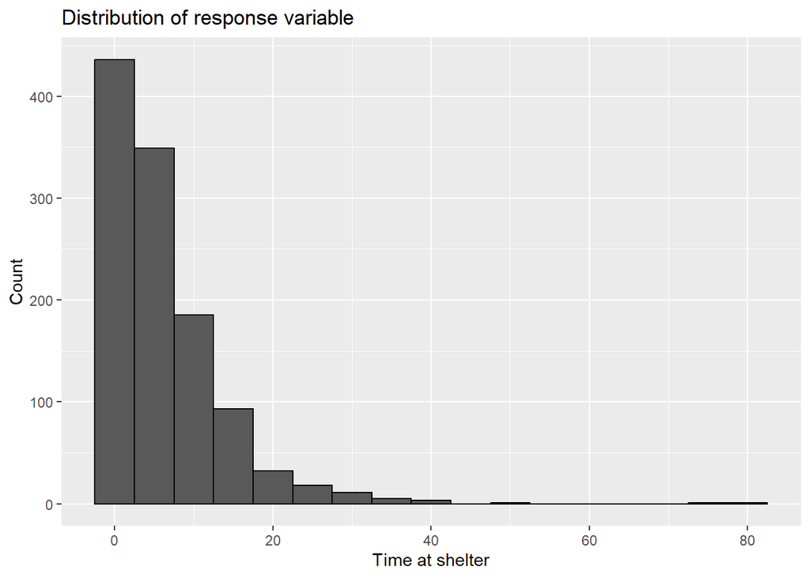

Now, let’s look at the correlation between time of the year and the time an animal spent at the shelter.

```
         cor
1 0.02348225
```

The above coefficient states that there is very weak positive correlation between an animals time at shelter and the month of an year.

Looking at the summary stats for response when grouped by the type of animals-

```
# A tibble: 5 × 7
  animal_type count median  mean Std_Dev quantile_25 quantile_75
  <chr>       <int>  <dbl> <dbl>   <dbl>       <dbl>       <dbl>
1 BIRD            2    0    0       0            0             0
2 CAT           238    3    5.43    8.25         0             7
3 DOG           880    4    6.36    7.17         1            10
4 LIVESTOCK       1    0    0      NA            0             0
5 WILDLIFE       14    3.5  3.79    4.61         0.5           4
```

Boxplot depicting the summary stats above can be seen as-

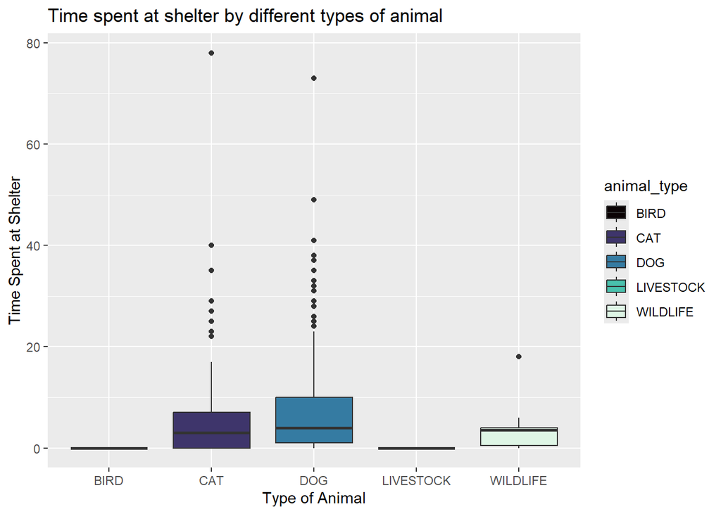

It can be clearly seen that both BIRD and LIVESTOCK spent zero days at the shelter, whereas there are some significant outliers for DOGS and CATS where median time is four and three days respectively but some recorded dogs and cats spent more than twenty days and the extremes being around seventy days.

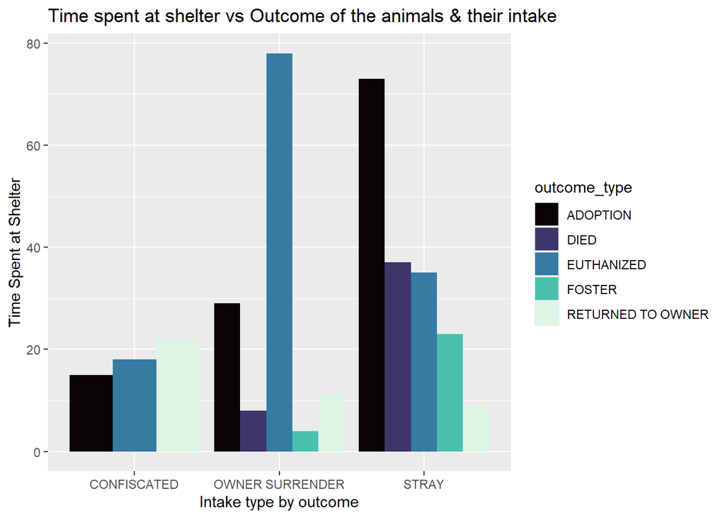

It can be seen from the column graph that the animal that spent the most time at shelter where the intake was owner surrendering was Euthanize and where intake was stray they were adopted at the end.

## Remove irrelevant categories

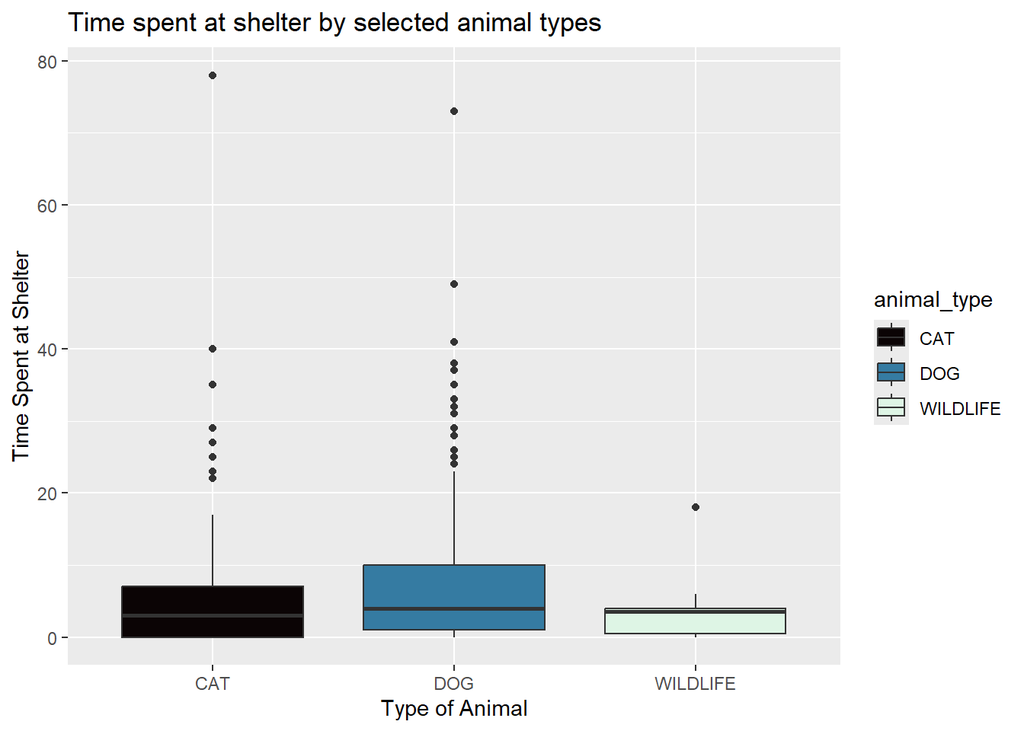

## Model fit

From the explanatory analysis part we can see that our response variable is count data and the distribution shows an exponential trend. Therefore Poisson regression and negative binominal regression are potentially suitable for the data.

```
Call:
glm(formula = time_at_shelter ~ animal_type + intake_type + chip_status,
    family = poisson(link = "log"), data = animal.sub)

Coefficients:
                           Estimate Std. Error z value Pr(>|z|)
(Intercept)                 2.37454    0.05611  42.316  < 2e-16 ***
animal_typeDOG              0.08646    0.03149   2.745 0.006044 **
animal_typeWILDLIFE        -0.21505    0.14068  -1.529 0.126371
intake_typeOWNER SURRENDER -0.74167    0.04692 -15.806  < 2e-16 ***
intake_typeSTRAY           -0.46854    0.04339 -10.799  < 2e-16 ***
chip_statusSCAN NO CHIP    -0.11288    0.03075  -3.671 0.000242 ***
chip_statusUNABLE TO SCAN  -0.63553    0.07381  -8.610  < 2e-16 ***
---
Signif. codes:  0 '***' 0.001 '**' 0.01 '*' 0.05 '.' 0.1 ' ' 1

(Dispersion parameter for poisson family taken to be 1)

    Null deviance: 8459.0  on 1131  degrees of freedom
Residual deviance: 8104.2  on 1125  degrees of freedom
AIC: 11214

Number of Fisher Scoring iterations: 6
```

From the model result, we conclude that only the coefficient of animal_type at level “WILDLIFE” is not statistically significant under the 95% confidence level, meaning when animal type changes from cat to wildlife the time at shelter is not expected to have a significant change.

We carry out a chi-square test to see if the model is a good fit and return the p-value.

```
[1] 1.478603e-73
```

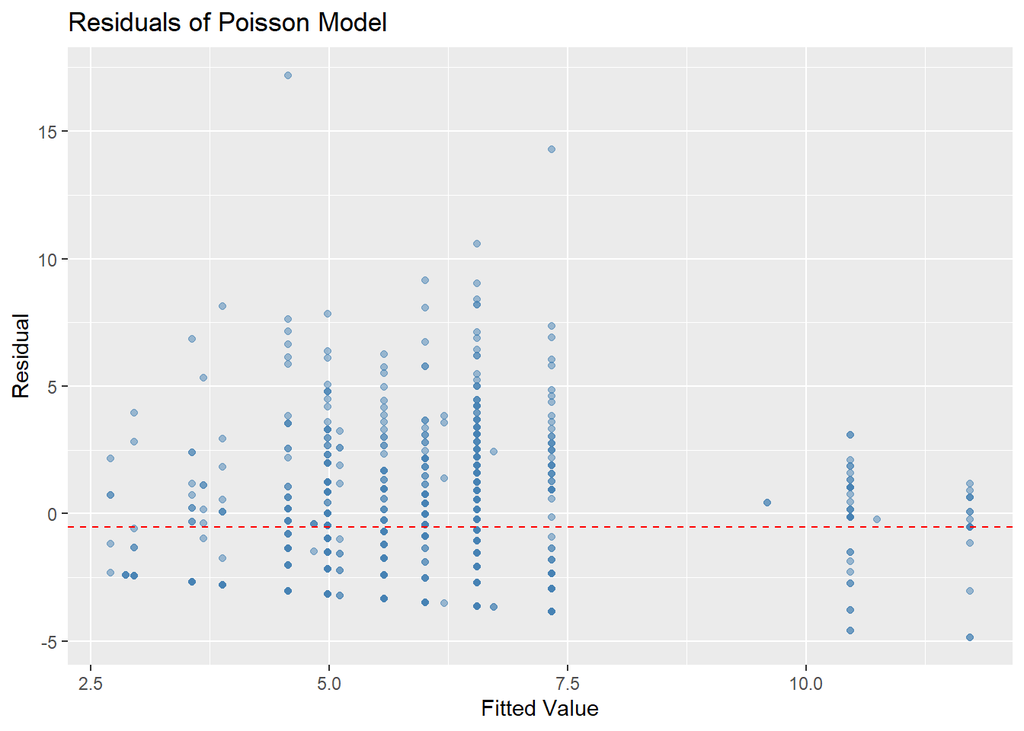

From the plot, we can see the residual deviances of the Poisson model seem to have 0 mean. But the variance seems larger on the positive side.

However, Poisson regression assumes that the mean and variance of the response variable are equal. We use a dispersion test to test if the Poisson regression is appropriate for our dataset.

```
    Overdispersion test

data:  model_poi
z = 6.222, p-value = 2.455e-10
alternative hypothesis: true dispersion is greater than 1
sample estimates:
dispersion
  8.897076
```

As we can see the p-value is smaller than 0.05, suggesting it is not appropriate to use a Poisson model due to the overdispersion of the response variable.

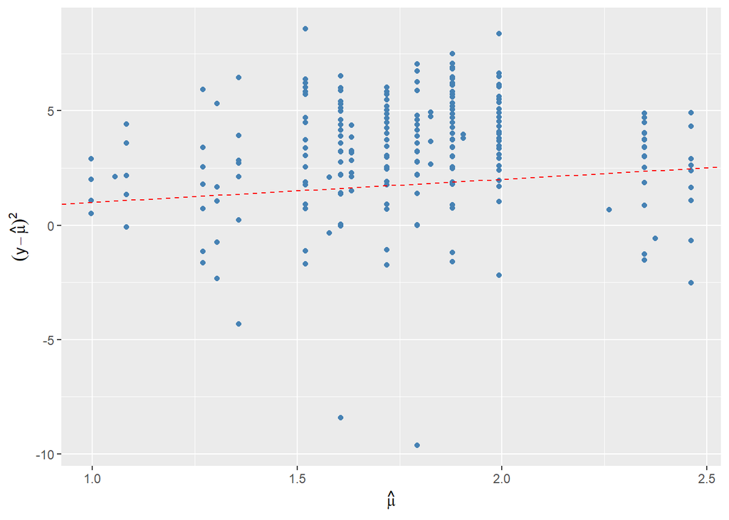

If Var(𝑌𝑖) > 𝜇𝑖 we say that we have **overdispersion**. This appears to be the case for the animals data – notice in the figure above that lot of the points lie above the line of equality for mean and variance.

Therefore we try to fit a negative binomial model to overcome this problem.

```
Call:
glm.nb(formula = time_at_shelter ~ animal_type + intake_type +
    chip_status, data = animal.sub, init.theta = 0.7244794593,
    link = log)

Coefficients:
                           Estimate Std. Error z value Pr(>|z|)
(Intercept)                 2.44560    0.19920  12.277  < 2e-16 ***
animal_typeDOG              0.04462    0.09316   0.479 0.631951
animal_typeWILDLIFE        -0.27976    0.35614  -0.786 0.432148
intake_typeOWNER SURRENDER -0.76950    0.17235  -4.465 8.02e-06 ***
intake_typeSTRAY           -0.51004    0.16621  -3.069 0.002150 **
chip_statusSCAN NO CHIP    -0.11328    0.09813  -1.154 0.248328
chip_statusUNABLE TO SCAN  -0.69100    0.19205  -3.598 0.000321 ***
---
Signif. codes:  0 '***' 0.001 '**' 0.01 '*' 0.05 '.' 0.1 ' ' 1

(Dispersion parameter for Negative Binomial(0.7245) family taken to be 1)

    Null deviance: 1340.0  on 1131  degrees of freedom
Residual deviance: 1302.3  on 1125  degrees of freedom
AIC: 6473.3

Number of Fisher Scoring iterations: 1

              Theta:  0.7245
          Std. Err.:  0.0375

 2 x log-likelihood:  -6457.3450
```

```
[1] 1.157618
```

```
Call:
glm.nb(formula = time_at_shelter ~ animal_type + intake_type +
    chip_status, data = animal.sub, init.theta = 0.7244794593,
    link = log)

Coefficients:
                           Estimate Std. Error z value Pr(>|z|)
(Intercept)                 2.44560    0.21433  11.410  < 2e-16 ***
animal_typeDOG              0.04462    0.10024   0.445 0.656189
animal_typeWILDLIFE        -0.27976    0.38318  -0.730 0.465336
intake_typeOWNER SURRENDER -0.76950    0.18544  -4.150 3.33e-05 ***
intake_typeSTRAY           -0.51004    0.17883  -2.852 0.004342 **
chip_statusSCAN NO CHIP    -0.11328    0.10558  -1.073 0.283292
chip_statusUNABLE TO SCAN  -0.69100    0.20663  -3.344 0.000825 ***
---
Signif. codes:  0 '***' 0.001 '**' 0.01 '*' 0.05 '.' 0.1 ' ' 1

(Dispersion parameter for Negative Binomial(0.7245) family taken to be 1.157618)

    Null deviance: 1340.0  on 1131  degrees of freedom
Residual deviance: 1302.3  on 1125  degrees of freedom
AIC: 6473.3

Number of Fisher Scoring iterations: 1

              Theta:  0.7245
          Std. Err.:  0.0375

 2 x log-likelihood:  -6457.3450
```

With the use of the estimated dispersion parameter the Wald tests are not very reliable, so we turn to an F test to determine the significance of the regression coefficients:

```
Single term deletions

Model:
time_at_shelter ~ animal_type + intake_type + chip_status
            Df Deviance    AIC F value   Pr(>F)
<none>           1302.3 6471.3
animal_type  2   1303.3 6468.3  0.4193 0.657585
intake_type  2   1326.5 6491.5 10.4457  3.2e-05 ***
chip_status  2   1314.3 6479.3  5.1688 0.005827 **
---
Signif. codes:  0 '***' 0.001 '**' 0.01 '*' 0.05 '.' 0.1 ' ' 1
```

Judging from the p-value, all levels of animal type are not significant at 95% confidence level. We take out animal type and fit a new negative binomial model.

```
Call:
glm.nb(formula = time_at_shelter ~ intake_type + chip_status,
    data = animal.sub, init.theta = 0.7236588999, link = log)

Coefficients:
                           Estimate Std. Error z value Pr(>|z|)
(Intercept)                 2.49906    0.17238  14.497  < 2e-16 ***
intake_typeOWNER SURRENDER -0.78827    0.17163  -4.593 4.37e-06 ***
intake_typeSTRAY           -0.51691    0.16568  -3.120 0.001809 **
chip_statusSCAN NO CHIP    -0.12660    0.09692  -1.306 0.191462
chip_statusUNABLE TO SCAN  -0.71276    0.18857  -3.780 0.000157 ***
---
Signif. codes:  0 '***' 0.001 '**' 0.01 '*' 0.05 '.' 0.1 ' ' 1

(Dispersion parameter for Negative Binomial(0.7237) family taken to be 1)

    Null deviance: 1339.0  on 1131  degrees of freedom
Residual deviance: 1302.3  on 1127  degrees of freedom
AIC: 6470.3

Number of Fisher Scoring iterations: 1

              Theta:  0.7237
          Std. Err.:  0.0375

 2 x log-likelihood:  -6458.3150
```

From the summary, we can see that only the coefficient of chip_status at level “SCAN NO CHIP” is not statistically significant, meaning when chip status changes from scan chip to scan no chip the time at shelter is not expected to have a significant change.

We carry out a chi-square test to see if the model is a good fit and return the p-value.

```
[1] 2.064469e-07
```

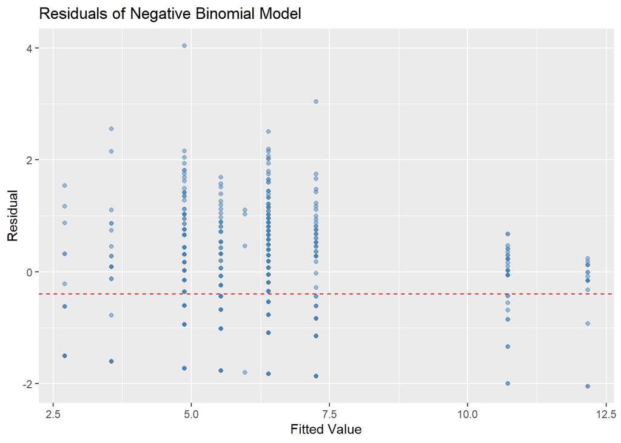

As shown in the plot, it seems fair to say that the residuals have 0 mean and constant variance.

By comparing the Poisson model and the second negative binomial model, we can see that the AIC value for the second negative binomial model is lower, and the residuals are smaller and more constant.

Therefore we consider our second negative binomial model as our final model.

Holding all other variables in the model constant, the coefficient of intake_type “OWNER SURRENDER” indicates that when the intake type is surrender, log(time at shelter) is expected to decrease by -0.79 compared to when intake type is confiscated, corresponding to a 54.54% decrease in time at shelter on average.

Holding all other variables in the model constant, the coefficient of intake_type “STRAY” indicates that when the intake type is stray, log(time at shelter) is expected to decrease by -0.52 compared to when intake type is confiscated, corresponding to a 40.36% decrease in time at shelter on average.

Judging from the p-value, the coefficient of chip_status “SCAN NO CHIP” is not statistically significant under the 95% confidence level, which means that holding all other variables in the model constant, the time at shelter when animal chip status is scan no chip is not expected to be significantly different than when animal chip status is scan chip.

Holding all other variables in the model constant, the coefficient of chip_status “UNABLE TO SCAN” indicates that when the chip status is unable to scan, log(time at shelter) is expected to decrease by -0.71 compared to when ship status is scan chip, corresponding to a 50.97% decrease in time at shelter on average.

### Model from Advanced Predictive Modelling

Sometimes overdispersion is observed due to excess zeros in the data. It can be seen that our model has about 25% of observation consisting of zero values which is a significant amount. The zeros represent **immediate outcomes**, which are structurally different from positive shelter times.

### Zero-Inflated model

In zero-inflated negative binomial models, we assume that there are two processes. One is a logistic process(immediate return or not) and the other models the non-zero counts with a neg binomial process and the resulting data distribution is a mixture of the two.

```
Call:
zeroinfl(formula = time_at_shelter ~ animal_type + intake_type + chip_status,
    data = animal.sub, dist = "negbin")

Pearson residuals:
    Min      1Q  Median      3Q     Max
-1.0761 -0.7575 -0.3582  0.3564 12.2579

Count model coefficients (negbin with log link):
                           Estimate Std. Error z value Pr(>|z|)
(Intercept)                 2.76187    0.16773  16.466  < 2e-16 ***
animal_typeDOG             -0.22121    0.08696  -2.544   0.0110 *
animal_typeWILDLIFE        -0.33457    0.31550  -1.060   0.2889
intake_typeOWNER SURRENDER -0.70398    0.13853  -5.082 3.74e-07 ***
intake_typeSTRAY           -0.32655    0.13014  -2.509   0.0121 *
chip_statusSCAN NO CHIP    -0.19322    0.08330  -2.320   0.0204 *
chip_statusUNABLE TO SCAN  -0.37750    0.19464  -1.939   0.0524 .
Log(theta)                  0.33390    0.08217   4.064 4.83e-05 ***

Zero-inflation model coefficients (binomial with logit link):
                           Estimate Std. Error z value Pr(>|z|)
(Intercept)                 -1.8373     0.9978  -1.841   0.0656 .
animal_typeDOG              -1.2042     0.2316  -5.199    2e-07 ***
animal_typeWILDLIFE         -0.6796     0.7349  -0.925   0.3551
intake_typeOWNER SURRENDER   1.0884     0.9802   1.110   0.2668
intake_typeSTRAY             1.6667     0.9614   1.734   0.0830 .
chip_statusSCAN NO CHIP     -0.5124     0.2879  -1.780   0.0751 .
chip_statusUNABLE TO SCAN    0.9262     0.4176   2.218   0.0266 *
---
Signif. codes:  0 '***' 0.001 '**' 0.01 '*' 0.05 '.' 0.1 ' ' 1

Theta = 1.3964
Number of iterations in BFGS optimization: 21
Log-likelihood: -3171 on 15 Df
```

The model comparison by AIC value is carried out.

```
           df      AIC
model_nb2   6 6470.315
zinb_model 15 6371.356
```

It can be seen that the model now fits the data slightly better when comparing the AIC values.